# Homework 4

Modified

Tu 2023-03-14 14:21

Due

Fr 2023-03-24 14:00

Do the following in non-engineering format.

1. Convert the list of nontraditional units shown below into only primary standard units for the SI system. Be sure to show the derivation
   1. Donkeypower
   2. Friedman
   3. Wiffle
   4. Foe
   5. Long Ton
2. Convert the list of derived units shown below into only primary standard units for the SI system. Be sure to show the derivation.
   1. Tesla
   2. Katal
   3. Gray
   4. Weber
   5. MPG
3. Write a Python script that converts between different units of pressure. It should be able to convert units of $Pa$, $kPa$, $MPa$, $atm$, $psi$, $\frac{lbf}{ft^2}$, $torr$, $inHg$, and $mmHg$. Name the function `pressCon`. Run the code below to test the function your created. In your homework, include your function as well as the output of the script shown in Figure 1.

**Note**

The `pressCon` function should be located in a file called `pressure_converter.py` located in the same directory as the test script shown in Figure 1.

Figure 1: Test Script

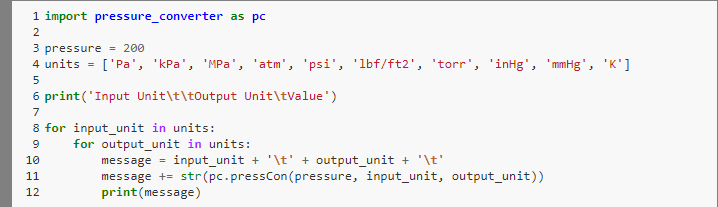

Using the Excel sheet for the Body Fat dataset found here complete the following problems. See here for a description of the dataset.

4. Using Python plot the body fat (Brozek) data against the weight, height, neck circumference, thigh circumference, and extended bicep circumference. You should have three separate plots. One with body fat versus weight, one with body fat versus height, and one with body fat versus neck, thigh, and bicep circumference as separate series. Be sure to include a legend on the multi-series plot. Remember, body fat is the dependent variable in this study so it should go on the y-axis.
5. Using Python calculate the average weight and body fat (Brozek) of each group of men in their 20s, 30s, 40s, 50s, 60s, and 70s. Plot the average values as a single bar plot with two series. The first series is for the weight, and the second is for the body fat. Be sure to include a legend and properly label the $x$ and $y$ axes.

Homework submission should be made on Moodle.